# Machine Learning: AllLife Bank Personal Loan Campaign

## Problem Statement

### Context

AllLife Bank is a US bank that has a growing customer base. The majority of these customers are liability customers (depositors) with varying sizes of deposits. The number of customers who are also borrowers (asset customers) is quite small, and the bank is interested in expanding this base rapidly to bring in more loan business and in the process, earn more through the interest on loans. In particular, the management wants to explore ways of converting its liability customers to personal loan customers (while retaining them as depositors).

A campaign that the bank ran last year for liability customers showed a healthy conversion rate of over 9% success. This has encouraged the retail marketing department to devise campaigns with better target marketing to increase the success ratio.

You as a Data scientist at AllLife bank have to build a model that will help the marketing department to identify the potential customers who have a higher probability of purchasing the loan.

### Objective

To predict whether a liability customer will buy personal loans, to understand which customer attributes are most significant in driving purchases, and identify which segment of customers to target more.

### Data Dictionary

- `ID`: Customer ID
- `Age`: Customer’s age in completed years
- `Experience`: #years of professional experience
- `Income`: Annual income of the customer (in thousand dollars)
- `ZIP Code`: Home Address ZIP code.
- `Family`: the Family size of the customer
- `CCAvg`: Average spending on credit cards per month (in thousand dollars)
- `Education`: Education Level. 1: Undergrad; 2: Graduate;3: Advanced/Professional
- `Mortgage`: Value of house mortgage if any. (in thousand dollars)
- `Personal_Loan`: Did this customer accept the personal loan offered in the last campaign? (0: No, 1: Yes)
- `Securities_Account`: Does the customer have securities account with the bank? (0: No, 1: Yes)
- `CD_Account`: Does the customer have a certificate of deposit (CD) account with the bank? (0: No, 1: Yes)
- `Online`: Do customers use internet banking facilities? (0: No, 1: Yes)
- `CreditCard`: Does the customer use a credit card issued by any other Bank (excluding All life Bank)? (0: No, 1: Yes)

## Importing necessary libraries

```python
# Installing the libraries with the specified version.
!pip install numpy==1.25.2 pandas==1.5.3 matplotlib==3.7.1 seaborn==0.13.1 scikit-learn==1.2.2 sklearn-pandas==2.2.0 -q --user
```

**Note**: *After running the above cell, kindly restart the notebook kernel and run all cells sequentially from the start again.*

```python
 # Libraries to help with reading and manipulating data
import pandas as pd
import numpy as np

# libaries to help with data visualization
import matplotlib.pyplot as plt
import seaborn as sns

# Removes the limit for the number of displayed columns
pd.set_option("display.max_columns", None)

# Sets the limit for the number of displayed rows
pd.set_option("display.max_rows", 200)

# Library to split data
from sklearn.model_selection import train_test_split

# To build model for prediction
from sklearn.tree import DecisionTreeClassifier
from sklearn import tree

# To tune different models
from sklearn.model_selection import GridSearchCV

# To get diferent metric scores
from sklearn.metrics import (
    f1_score,
    accuracy_score,
    recall_score,
    precision_score,
    confusion_matrix,
    make_scorer,
)

# Ignore waringings as they do not affect the code
import warnings
warnings.filterwarnings("ignore")

 # Set defaults for seaborn Library
 sns.set()
```

## Loading the dataset

```python
# Define the path to the dataset
file_path = '/home/critter/Learning/data/Loan_Modelling.csv'

# Open and read the data
df = pd.read_csv(file_path)

# Create a copy of the data to avoid changes to the original data
data = df.copy()
```

## Data overview

### Overview of the dataset

```python
# Viewing the first five rows of the data
data.head()
```

|  | ID | Age | Experience | Income | ZIPCode | Family | CCAvg | Education | Mortgage | Personal_Loan | Securities_Account | CD_Account | Online | CreditCard |
| --- | --- | --- | --- | --- | --- | --- | --- | --- | --- | --- | --- | --- | --- | --- |
| 0 | 1 | 25 | 1 | 49 | 91107 | 4 | 1.6 | 1 | 0 | 0 | 1 | 0 | 0 | 0 |
| 1 | 2 | 45 | 19 | 34 | 90089 | 3 | 1.5 | 1 | 0 | 0 | 1 | 0 | 0 | 0 |
| 2 | 3 | 39 | 15 | 11 | 94720 | 1 | 1.0 | 1 | 0 | 0 | 0 | 0 | 0 | 0 |
| 3 | 4 | 35 | 9 | 100 | 94112 | 1 | 2.7 | 2 | 0 | 0 | 0 | 0 | 0 | 0 |
| 4 | 5 | 35 | 8 | 45 | 91330 | 4 | 1.0 | 2 | 0 | 0 | 0 | 0 | 0 | 1 |

```python
# Viewing the last five rows of data
data.tail()
```

|  | ID | Age | Experience | Income | ZIPCode | Family | CCAvg | Education | Mortgage | Personal_Loan | Securities_Account | CD_Account | Online | CreditCard |
| --- | --- | --- | --- | --- | --- | --- | --- | --- | --- | --- | --- | --- | --- | --- |
| 4995 | 4996 | 29 | 3 | 40 | 92697 | 1 | 1.9 | 3 | 0 | 0 | 0 | 0 | 1 | 0 |
| 4996 | 4997 | 30 | 4 | 15 | 92037 | 4 | 0.4 | 1 | 85 | 0 | 0 | 0 | 1 | 0 |
| 4997 | 4998 | 63 | 39 | 24 | 93023 | 2 | 0.3 | 3 | 0 | 0 | 0 | 0 | 0 | 0 |
| 4998 | 4999 | 65 | 40 | 49 | 90034 | 3 | 0.5 | 2 | 0 | 0 | 0 | 0 | 1 | 0 |
| 4999 | 5000 | 28 | 4 | 83 | 92612 | 3 | 0.8 | 1 | 0 | 0 | 0 | 0 | 1 | 1 |

### Understand the shape of the dataset

```python
# Checking the shape of the data (number of rows and columns)
data.shape
rows, columns = data.shape
print(f"Number of rows: {rows}")
print(f"Number of columns: {columns}")
```

```
Number of rows: 5000
Number of columns: 14
```

### Checking the data types of the columns of the dataset

```python
# Checkng the data types of the columns in the dataset
data.info()
```

```
<class 'pandas.core.frame.DataFrame'>
RangeIndex: 5000 entries, 0 to 4999
Data columns (total 14 columns):
 #   Column              Non-Null Count  Dtype
---  ------              --------------  -----
 0   ID                  5000 non-null   int64
 1   Age                 5000 non-null   int64
 2   Experience          5000 non-null   int64
 3   Income              5000 non-null   int64
 4   ZIPCode             5000 non-null   int64
 5   Family              5000 non-null   int64
 6   CCAvg               5000 non-null   float64
 7   Education           5000 non-null   int64
 8   Mortgage            5000 non-null   int64
 9   Personal_Loan       5000 non-null   int64
 10  Securities_Account  5000 non-null   int64
 11  CD_Account          5000 non-null   int64
 12  Online              5000 non-null   int64
 13  CreditCard          5000 non-null   int64
dtypes: float64(1), int64(13)
memory usage: 547.0 KB
```

### Checking for missing values

```python
# Checking for missing values
data.isnull().sum()
```

```
ID                    0
Age                   0
Experience            0
Income                0
ZIPCode               0
Family                0
CCAvg                 0
Education             0
Mortgage              0
Personal_Loan         0
Securities_Account    0
CD_Account            0
Online                0
CreditCard            0
dtype: int64
```

**Observations**

- There is no missing values in the dataset

### Checking for duplicate values in the data set

```python
# print duplicate values
print(data[data.duplicated(keep=False)])
```

```
Empty DataFrame
Columns: [ID, Age, Experience, Income, ZIPCode, Family, CCAvg, Education, Mortgage, Personal_Loan, Securities_Account, CD_Account, Online, CreditCard]
Index: []
```

```python
# Check for duplicate values in ID column
data['ID'].duplicated().sum()
```

```
0
```

**Observations**

- There are no duplicate values in ID (Customer ID). Therefore, there are no duplicate values in this column.
- Duplicate values are expected in the other columns

### Dropping columns

**We will drop the ID column as it does not add any value to the analysis**

```python
data.drop(columns=['ID'],inplace=True)
```

### Check the statistical summary of the data

```python
# Checking the statistical summary of the data
data.describe().T
```

|  | count | mean | std | min | 25% | 50% | 75% | max |
| --- | --- | --- | --- | --- | --- | --- | --- | --- |
| Age | 5000.0 | 45.338400 | 11.463166 | 23.0 | 35.0 | 45.0 | 55.0 | 67.0 |
| Experience | 5000.0 | 20.104600 | 11.467954 | -3.0 | 10.0 | 20.0 | 30.0 | 43.0 |
| Income | 5000.0 | 73.774200 | 46.033729 | 8.0 | 39.0 | 64.0 | 98.0 | 224.0 |
| ZIPCode | 5000.0 | 93169.257000 | 1759.455086 | 90005.0 | 91911.0 | 93437.0 | 94608.0 | 96651.0 |
| Family | 5000.0 | 2.396400 | 1.147663 | 1.0 | 1.0 | 2.0 | 3.0 | 4.0 |
| CCAvg | 5000.0 | 1.937938 | 1.747659 | 0.0 | 0.7 | 1.5 | 2.5 | 10.0 |
| Education | 5000.0 | 1.881000 | 0.839869 | 1.0 | 1.0 | 2.0 | 3.0 | 3.0 |
| Mortgage | 5000.0 | 56.498800 | 101.713802 | 0.0 | 0.0 | 0.0 | 101.0 | 635.0 |
| Personal_Loan | 5000.0 | 0.096000 | 0.294621 | 0.0 | 0.0 | 0.0 | 0.0 | 1.0 |
| Securities_Account | 5000.0 | 0.104400 | 0.305809 | 0.0 | 0.0 | 0.0 | 0.0 | 1.0 |
| CD_Account | 5000.0 | 0.060400 | 0.238250 | 0.0 | 0.0 | 0.0 | 0.0 | 1.0 |
| Online | 5000.0 | 0.596800 | 0.490589 | 0.0 | 0.0 | 1.0 | 1.0 | 1.0 |
| CreditCard | 5000.0 | 0.294000 | 0.455637 | 0.0 | 0.0 | 0.0 | 1.0 | 1.0 |

**Observations**

## Data Processing part 1

### Checking for anomalous data

```python
# Check what unique values are in Experience
data['Experience'].unique()
```

```
array([ 1, 19, 15,  9,  8, 13, 27, 24, 10, 39,  5, 23, 32, 41, 30, 14, 18,
       21, 28, 31, 11, 16, 20, 35,  6, 25,  7, 12, 26, 37, 17,  2, 36, 29,
        3, 22, -1, 34,  0, 38, 40, 33,  4, -2, 42, -3, 43])
```

- Experience has some negative values that are not correct (-1, -2 and -3). For this analysis, I am going to convert those to positive numbers of the same value.

```python
# Correcting the experience values
data["Experience"].replace(-1, 1, inplace=True)
data["Experience"].replace(-2, 2, inplace=True)
data["Experience"].replace(-3, 3, inplace=True)
```

```python
# verify the data is now correct
data['Experience'].unique()
```

```
array([ 1, 19, 15,  9,  8, 13, 27, 24, 10, 39,  5, 23, 32, 41, 30, 14, 18,
       21, 28, 31, 11, 16, 20, 35,  6, 25,  7, 12, 26, 37, 17,  2, 36, 29,
        3, 22, 34,  0, 38, 40, 33,  4, 42, 43])
```

### Zip Code analysis and fearure engineering

- My plan is to evaluate how many unique zip codes there are and reduce the digits of the zipcode untel we get a number that we can use realistically and meaningfully in this analysis.
- After looking at this, using the fist 2 digits looks like the right choice.

```python
# Count unique ZIP codes
unique_zip_codes = data["ZIPCode"].nunique()
print(f"Number of unique ZIP codes: {unique_zip_codes}")
```

```
Number of unique ZIP codes: 467
```

```python
# Process ZIPCode: truncate to first 2 digits and convert to categorical
data["ZIPCode"] = data["ZIPCode"].astype(str).str[:2].astype("category")
# Show the resutls
print(f"Number of unique ZIP code prefixes: {data['ZIPCode'].nunique()}")
```

```
Number of unique ZIP code prefixes: 7
```

### Convert binary variables to category type

```python
# Convert binary variables to 'category' type
cat_cols = [
    "Personal_Loan",
    "Securities_Account",
    "CD_Account",
    "Online",
    "CreditCard",
    "ZIPCode"
]
data[cat_cols] = data[cat_cols].astype("category")
```

```python
# Map the Education values into 1= Undergraduate, 2= Graduate, 3= Advanced/Professional
data['Education'].replace(1, 'Undergraduate', inplace=True)
data['Education'].replace(2, 'Graduate', inplace=True)
data['Education'].replace(3, 'Advanced/Professional', inplace=True)
```

## Exploratory Data Analysis.

```python
# Function to make a histogram and boxplot
def histogram_boxplot(data, feature, figsize=(12, 7), kde=False, bins=None):
    """
    Boxplot and histogram combined
    data: dataframe
    feature: dataframe column
    figsize: size of figure (default (12,7))
    kde: whether to show the density curve (default False)
    bins: number of bins for histogram (default None)
    """
    # Creating the 2 subplots
    # Number of rows of the subplot grid = 2
    # x-axis will be shared among all subplots
    f2, (ax_box2, ax_hist2) = plt.subplots(
        nrows=2,
        sharex=True,
        gridspec_kw={"height_ratios": (0.25, 0.75)},
        figsize=figsize,
    )

    # Boxplot will be created and a star will indicate the mean value of the column
    sns.boxplot(
        data=data, x=feature, ax=ax_box2, showmeans=True, color="violet"
    )

    # For histogram
    if bins:
        sns.histplot(
            data=data, x=feature, kde=kde, ax=ax_hist2, bins=bins, palette="winter"
        )
    else:
        sns.histplot(
            data=data, x=feature, kde=kde, ax=ax_hist2
        )

    # Add mean to the histogram
    ax_hist2.axvline(
        data[feature].mean(), color="green", linestyle="--"
    )

    # Add median to the histogram
    ax_hist2.axvline(
        data[feature].median(), color="black", linestyle="-"
    )
```

```python
# Function to create labeled barplots
def labeled_barplot(data, feature, perc=False, n=None):
    """
    Creates a bar plot with labels on top of each bar.

    Parameters:
    data (DataFrame): The input dataframe
    feature (str): The column name to be plotted
    perc (bool): If True, display percentages instead of counts (default False)
    n (int): Number of top categories to display (default None, displays all)
    """

    total = len(data[feature])  # Get total number of rows
    count = data[feature].nunique()  # Count unique values in the feature

    # Set figure size based on the number of categories
    if n is None:
        plt.figure(figsize=(count + 1, 5))
    else:
        plt.figure(figsize=(n + 1, 5))

    plt.xticks(rotation=90, fontsize=15)  # Rotate x-axis labels for readability

    # Create the count plot
    ax = sns.countplot(
        data=data,
        x=feature,
        palette="Paired",
        order=data[feature].value_counts().index[:n].sort_values(),
    )

    # Add labels on top of each bar
    for p in ax.patches:
        if perc:
            label = "{:.1f}%".format(100 * p.get_height() / total)  # Calculate percentage
        else:
            label = p.get_height()  # Use count

        # Calculate the position for the label
        x = p.get_x() + p.get_width() / 2
        y = p.get_height()

        # Add label to the plot
        ax.annotate(
            label,
            (x, y),
            ha="center",
            va="center",
            size=12,
            xytext=(0, 5),
            textcoords="offset points",
        )

    # Display the plot
    plt.show()
```

### Graphs and observations on Age

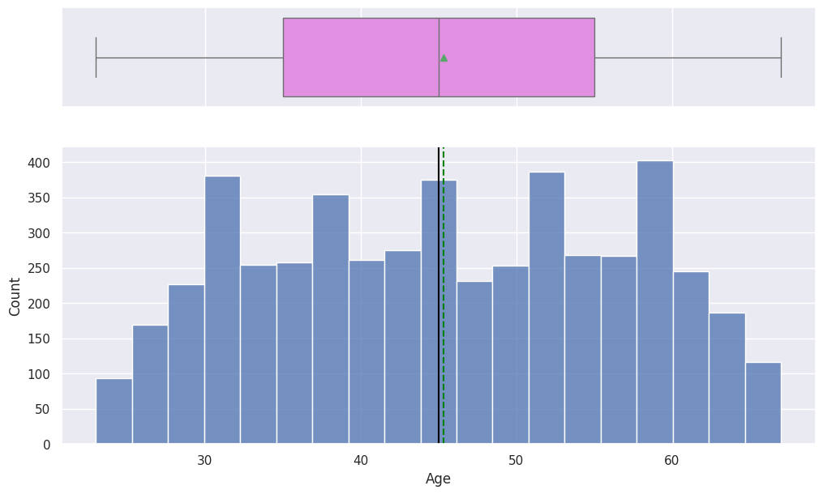

```python
histogram_boxplot(data, "Age")
```

**Observations**

### Graphs and observations on Experience

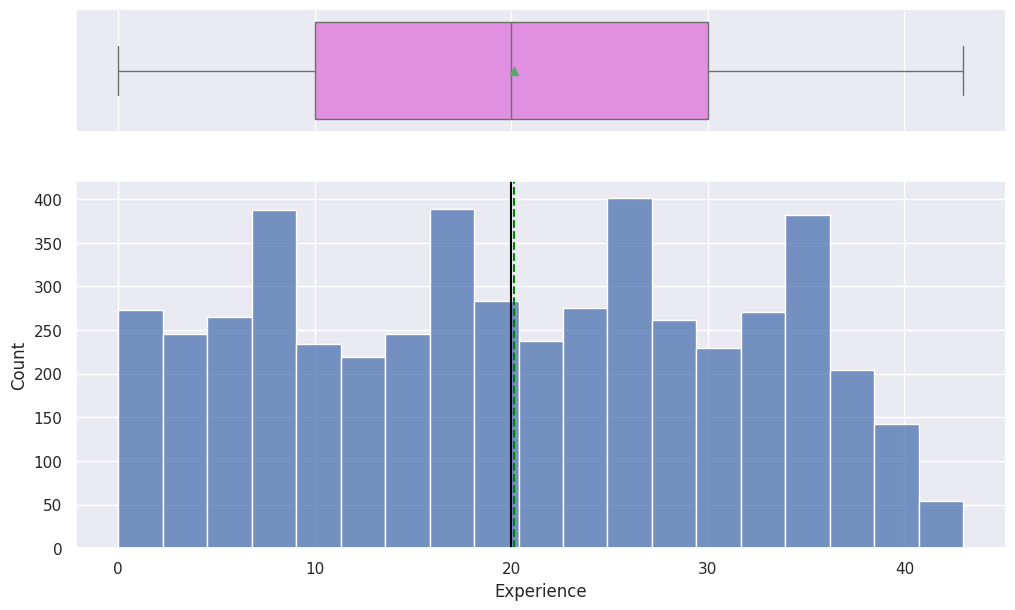

```python
histogram_boxplot(data, "Experience")
```

**Observations**

### Graphs and observations on Income

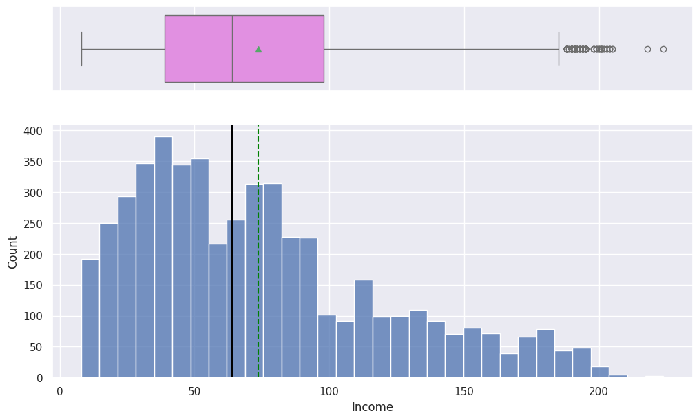

```python
histogram_boxplot(data, "Income")
```

**Observations**

- This variable is right-skewed
- There are many outliers above the 3rd quartile in this variable.

### Graphs and observations on CCAvg

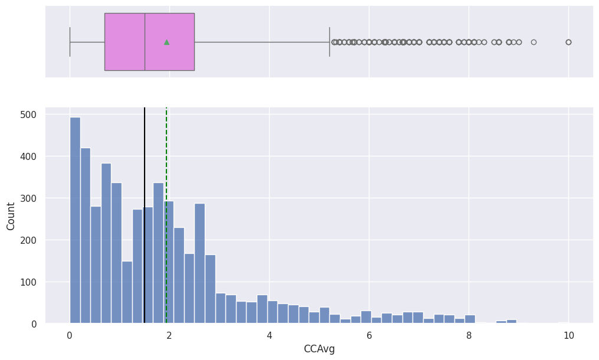

```python
histogram_boxplot(data, "CCAvg")
```

**Observations**

- This variable is right-skewed.
- There are many outliers above the 3rd quartile in this variable.

### Graphs and observations on Mortgage

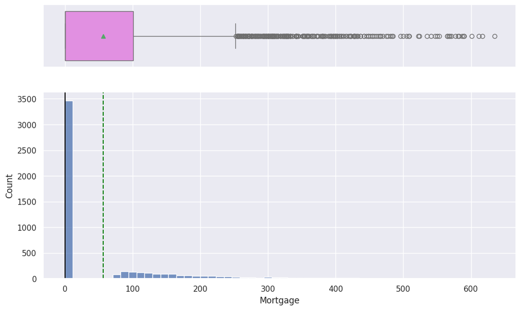

```python
histogram_boxplot(data, "Mortgage")
```

**Observations**

- This variable is heavily right-skewed.
- There are many outliers above the 3rd quartile in this variable.

### Graphs and observations on Family

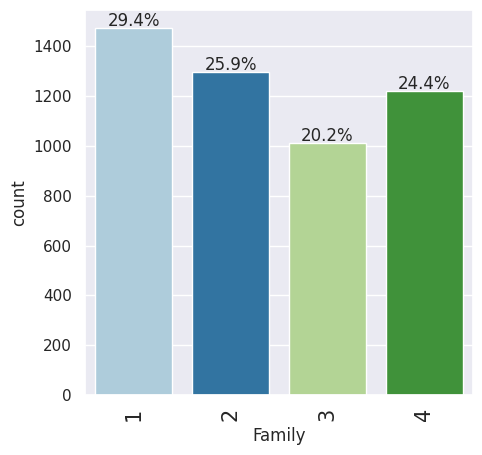

```python
labeled_barplot(data, "Family", perc=True)
```

**Observations**

### Graphs and observations on Education

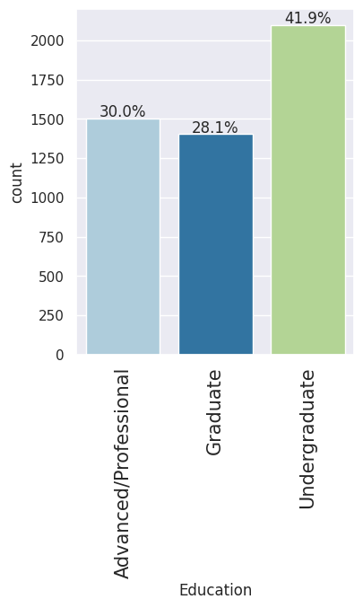

```python
labeled_barplot(data, "Education", perc=True)
```

**Observations**

- The majority (42%) of customers have an undergraduate level of education.
- 28% of customers have a graduate level of education.
- 30% of customers have advanced/professional education

### Graphs and observations on Securities Account

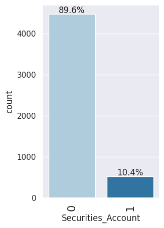

```python
labeled_barplot(data, "Securities_Account", perc=True)
```

**Observations**

- 89.6% of customers do not have a securities account

### Graphs and observations on CD_Account

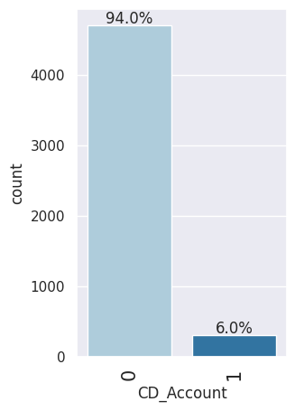

```python
labeled_barplot(data, "CD_Account", perc=True)
```

**Observations**

- 94% of customers do not have a CD account

### Graphs and observations on Online

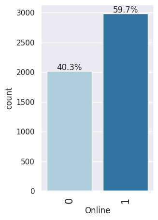

```python
labeled_barplot(data, "Online", perc=True)
```

**Observations**

- 59% of users do their banking online

### Graphs and observations on CreditCard

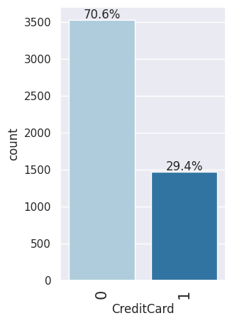

```python
labeled_barplot(data, "CreditCard", perc=True)
```

**Observations**

- 70% of customers do not have a credit card

### Graphs and observations on ZIPCode

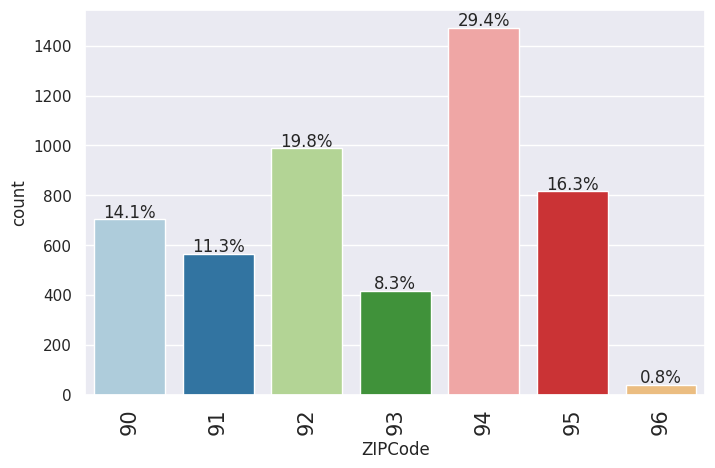

```python
labeled_barplot(data, "ZIPCode", perc=True)
```

**Observations**

- The majority of customers (29.4%) live in area 94.
- Very few customers (0.8%) live in area 96

## Bivariate Analysis

```python
# function to create stacked barplots
def stacked_barplot(data, predictor, target):
    """
    Print category counts and plot a stacked bar chart.

    Parameters:
    data (DataFrame): Input dataframe
    predictor (str): Independent variable column name
    target (str): Target variable column name
    """
    count = data[predictor].nunique()
    sorter = data[target].value_counts().index[-1]

    # Create and display cross-tabulation
    tab1 = pd.crosstab(data[predictor], data[target], margins=True).sort_values(by=sorter, ascending=False)
    print(tab1)
    print("-" * 120)

    # Create normalized cross-tabulation for plotting
    tab = pd.crosstab(data[predictor], data[target], normalize="index").sort_values(by=sorter, ascending=False)

 # Plot stacked bar chart
    ax = tab.plot(kind="bar", stacked=True, figsize=(count + 5, 5))

    # Adjust legend
    plt.legend(title=target, bbox_to_anchor=(1.05, 1), loc='upper left')

    # Rotate x-axis labels by 90 degrees
    plt.xticks(rotation=90)

    # Adjust layout to prevent cutting off labels
    plt.tight_layout()

    # Show the plot
    plt.show()

    return ax
```

```python
# function to plot distributions with regards to target
def distribution_plot_wrt_target(data, predictor, target):
    # Create a 2x2 subplot
    fig, axs = plt.subplots(2, 2, figsize=(12, 10))

    # Get unique values of the target variable
    target_uniq = data[target].unique()

    # Plot distribution for first target value
    axs[0, 0].set_title("Distribution of target for target=" + str(target_uniq[0]))
    sns.histplot(
        data=data[data[target] == target_uniq[0]],
        x=predictor,
        kde=True,
        ax=axs[0, 0],
        color="teal",
        stat="density",
    )

    # Plot distribution for second target value
    axs[0, 1].set_title("Distribution of target for target=" + str(target_uniq[1]))
    sns.histplot(
        data=data[data[target] == target_uniq[1]],
        x=predictor,
        kde=True,
        ax=axs[0, 1],
        color="orange",
        stat="density",
    )

    # Plot boxplot with respect to target
    axs[1, 0].set_title("Boxplot w.r.t target")
    sns.boxplot(data=data, x=target, y=predictor, ax=axs[1, 0], palette="gist_rainbow")

    # Plot boxplot without outliers
    axs[1, 1].set_title("Boxplot (without outliers) w.r.t target")
    sns.boxplot(
        data=data,
        x=target,
        y=predictor,
        ax=axs[1, 1],
        showfliers=False,
        palette="gist_rainbow",
    )

    # Adjust layout and display the plot
    plt.tight_layout()
    plt.show()
```

### Data Correleation check

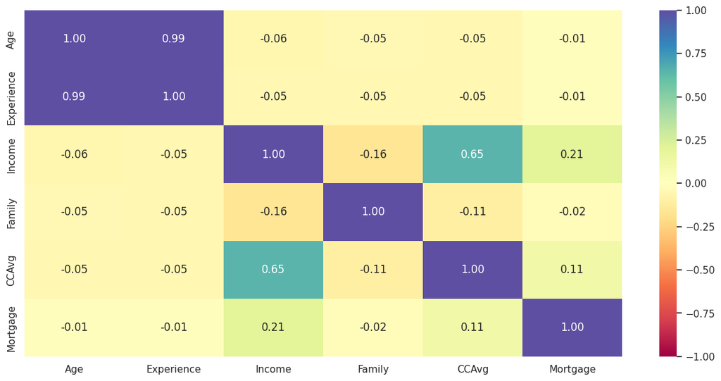

```python
# Create a heatmap of the correlation matrix of the data
plt.figure(figsize=(15, 7))
sns.heatmap(data.corr(), annot=True, vmin=-1, vmax=1, fmt=".2f", cmap="Spectral");
```

**Observations**

- There is an extremely strong correlation (0.99) between age and experience.
- There is a strong correlation (.65) between income and credit card average.

### Education vs Personal_loan

```
Personal_Loan             0    1   All
Education
All                    4520  480  5000
Advanced/Professional  1296  205  1501
Graduate               1221  182  1403
Undergraduate          2003   93  2096
------------------------------------------------------------------------------------------------------------------------
```

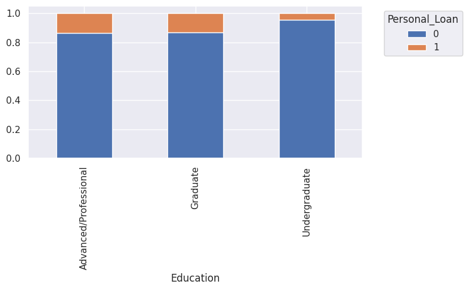

```python
stacked_barplot(data, "Education", "Personal_Loan");
```

**Observations**

- 90% of customers do not have a personal loan
- Customers with advanced/professional degrees are about three times more likely to have a personal loan than those with undergraduate degrees.
- Education of advanced/professional and graduates have similar rates of personal loans, both significantly higher than undergraduate.

### Personal_Loan vs Family

```
Personal_Loan     0    1   All
Family
All            4520  480  5000
4              1088  134  1222
3               877  133  1010
1              1365  107  1472
2              1190  106  1296
------------------------------------------------------------------------------------------------------------------------
```

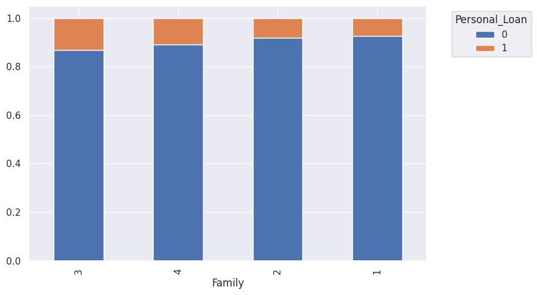

```python
stacked_barplot(data, "Family", "Personal_Loan");
```

**Observations**

- 90.4% of families do not have a personal loan
- Larger families (3 -4 persons) seem to have a higher percentage of personal loans compared to smaller families (1- 2 persons)

### Personal_Loan vs Securities_Account

```
Securities_Account     0    1   All
Personal_Loan
All                 4478  522  5000
0                   4058  462  4520
1                    420   60   480
------------------------------------------------------------------------------------------------------------------------
```

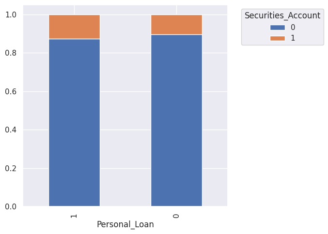

```python
stacked_barplot(data, 'Personal_Loan', 'Securities_Account');
```

**Observations**

- 89.6% of customers do not have a securities account
- There's a slightly higher percentage of securities account holders among those with personal loans (12.5%) than those without (10.22%).

### Personal_Loan vs CD_Account

```
CD_Account        0    1   All
Personal_Loan
All            4698  302  5000
0              4358  162  4520
1               340  140   480
------------------------------------------------------------------------------------------------------------------------
```

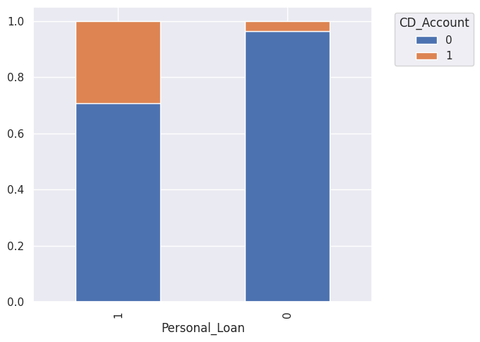

```python
stacked_barplot(data, 'Personal_Loan', 'CD_Account');
```

**Observations**

- 93% of customers do not have a CD account.
- There seems to be a higher proportion of individuals with a personal loan among those with a CD account than those who do not have a CD account.

### Personal_Loan vs Online

```
Online            0     1   All
Personal_Loan
All            2016  2984  5000
0              1827  2693  4520
1               189   291   480
------------------------------------------------------------------------------------------------------------------------
```

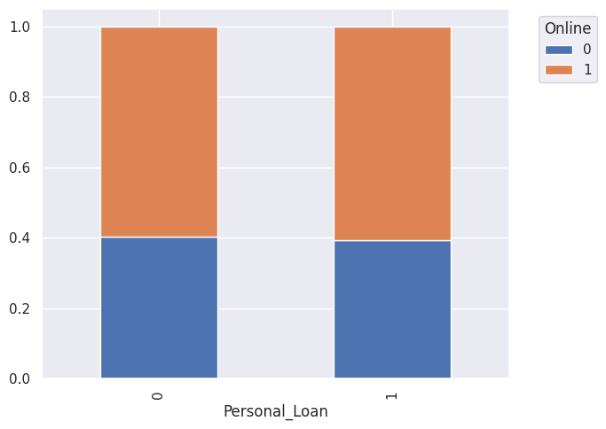

```python
stacked_barplot(data, 'Personal_Loan', 'Online');
```

**Observations**

- 59.68% of customers use online banking
- Online banking is more popular than traditional banking in this dataset, regardless of loan status

### Personal_Loan vs CreditCard

```
CreditCard        0     1   All
Personal_Loan
All            3530  1470  5000
0              3193  1327  4520
1               337   143   480
------------------------------------------------------------------------------------------------------------------------
```

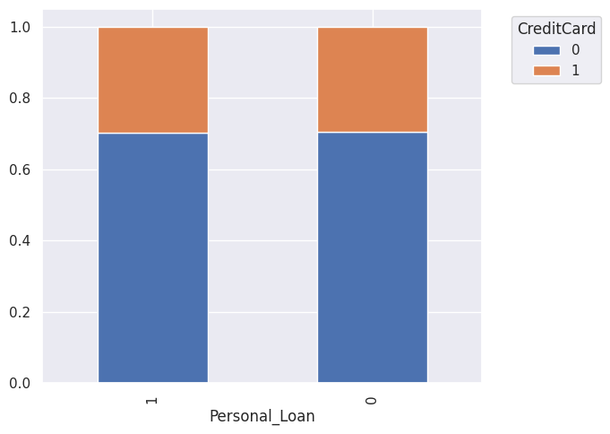

```python
stacked_barplot(data, 'Personal_Loan', 'CreditCard');
```

**Observations**

- 70.6% of customers do not have a credit card.
- There is little difference in credit card ownership rates between those customers with personal loans and those without.

### Personal_Loan vs ZIPCode

```
ZIPCode         90   91   92   93    94   95  96   All
Personal_Loan
All            703  565  988  417  1472  815  40  5000
0              636  510  894  374  1334  735  37  4520
1               67   55   94   43   138   80   3   480
------------------------------------------------------------------------------------------------------------------------
```

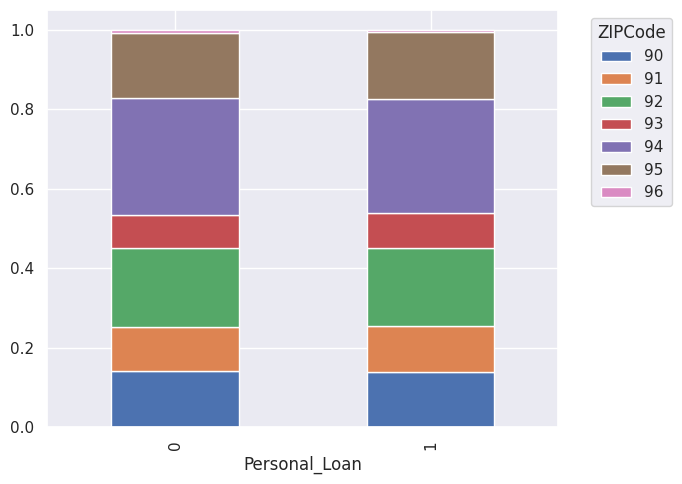

```python
stacked_barplot(data, 'Personal_Loan', 'ZIPCode');
```

**Observations**

- ZIP code 94 has the highest population (1472, 29.44% of the sample).
- ZIP code 96 has the lowest population (40, 0.8% of the sample).
- Personal loan rates are relatively consistent across most ZIP codes, ranging from 9.37% to 10.31% for ZIP codes 90-95.

### Personal_Loan vs Age

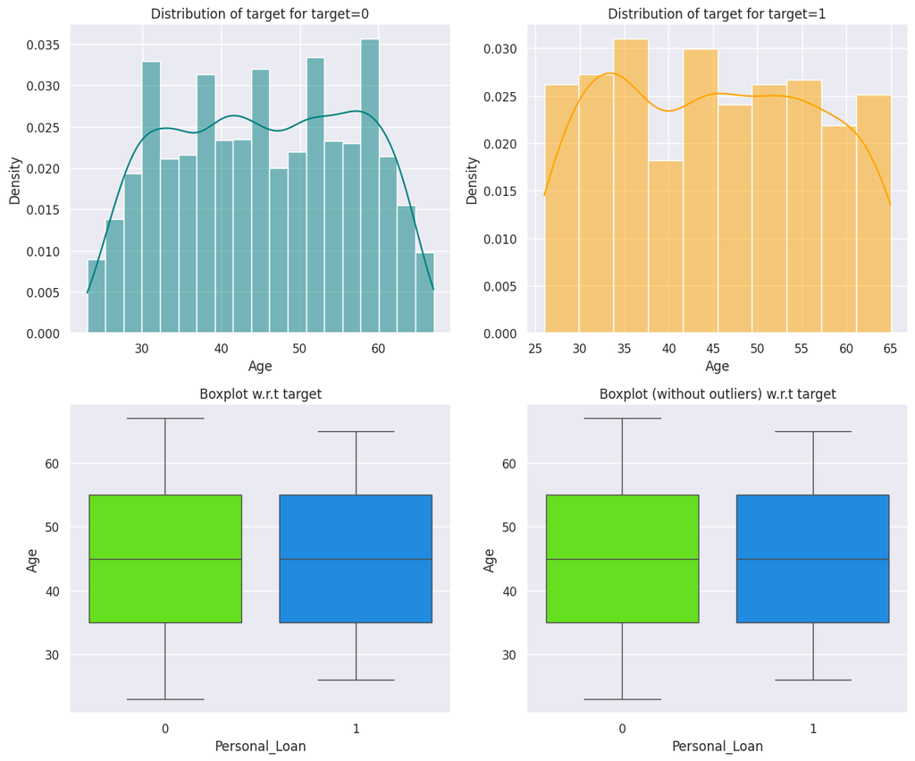

```python
distribution_plot_wrt_target(data, "Age", "Personal_Loan")
```

**Observations**

- Age vs personal loan data is normally distributed with no outliers
- Income, CCAvg, and Mortgage have a significant number of values above the 3rd quartile that are considered outliers. However, these values are legitimate and do not require outlier treatment.

### Personal Loan vs Experience

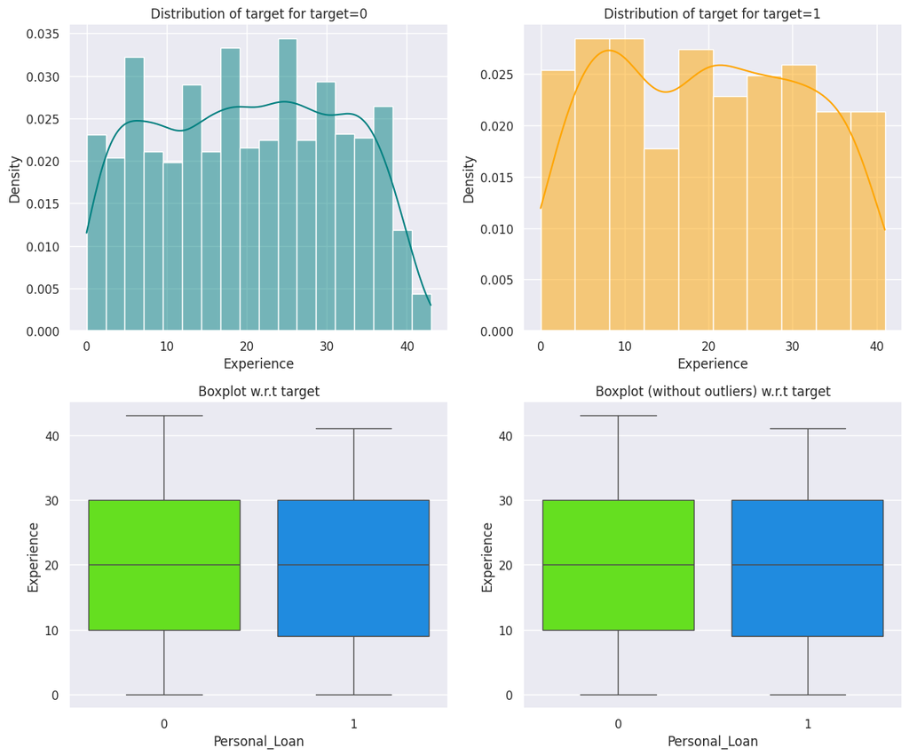

```python
distribution_plot_wrt_target(data, 'Experience', 'Personal_Loan');
```

**Observations**

### Personal Loan vs Income

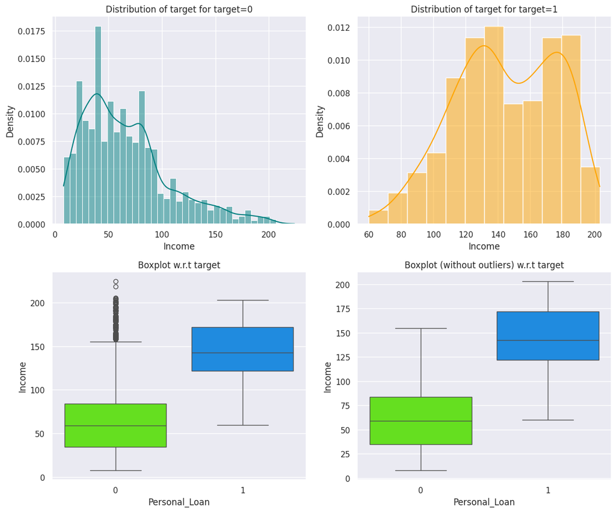

```python
distribution_plot_wrt_target(data, 'Income', 'Personal_Loan');
```

**Observations**

- The income vs. personal loan data is right-skewed for customers without personal loans.
- The income vs. personal loan data is slightly left-skewed for customers with personal loans.
- There are many outliers above the 3rd quartile.

### Personal Loan vs CCAvg

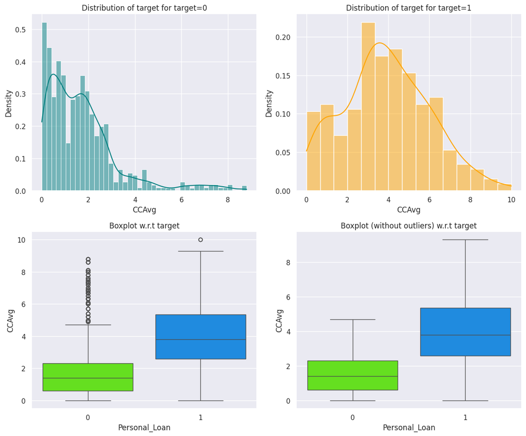

```python
distribution_plot_wrt_target(data, 'CCAvg', 'Personal_Loan');
```

**Observations**

- The CCCavg vs personal loan data is right-skewed.
- There are many outliers above the 3rd quartile.

**Questions**:

## Data Preprocessing

- Missing value treatment
- Feature engineering (if needed)
- Outlier detection and treatment (if needed)
- Preparing data for modeling
- Any other preprocessing steps (if needed)

## Model Building

### Outlier Detection

```python
# Find the 25th percentile and 75th percentile.
Q1 = data.quantile(0.25)
Q3 = data.quantile(0.75)

# Inter Quantile Range (75th percentile - 25th percentile)
IQR = Q3 - Q1

# Finding lower and upper bounds for all values. All values outside these bounds are outliers
lower = (
 Q1 - 1.5 * IQR
)
upper = Q3 + 1.5 * IQR
```

```python
# determine which values are below the lower bound
# and above the upper bound and convert this into a percentage
(
    (data.select_dtypes(include=["float64", "int64"]) < lower)
    | (data.select_dtypes(include=["float64", "int64"]) > upper)
).sum() / len(data) * 100
```

```
Age           0.00
Experience    0.00
Income        1.92
Family        0.00
CCAvg         6.48
Mortgage      5.82
dtype: float64
```

- Age and experience are highly correlated, so we can drop experience.
- Income, CCAvg, and Mortgage have a significant number of values above the 3rd quartile considered outliers. However, these values are legitimate and do not require outlier treatment.

### Data preperation for Modeling

**The heatmap shows that Age and Experience are very closely related (0.99), so Experience can be dropped**

```python
# Dropping Experience as it is closely correlated with Age
# Dropping Personal_Loan as it is the target variable we are predicting
X = data.drop(["Personal_Loan", "Experience"], axis=1)
Y = data["Personal_Loan"]

# One hot encoding categorical variables
X = pd.get_dummies(X, columns=["ZIPCode", "Education"], drop_first=True)
```

```python
# Splitting data in train and test sets
X_train, X_test, y_train, y_test = train_test_split(
    X, Y, test_size=0.30, random_state=1
)
```

```python
# Display data ab out the test and training sets
print("Shape of Training set : ", X_train.shape)
print("Shape of test set : ", X_test.shape)
print("Percentage of classes in training set:")
print(y_train.value_counts(normalize=True))
print("Percentage of classes in test set:")
print(y_test.value_counts(normalize=True))
```

```
Shape of Training set :  (3500, 17)
Shape of test set :  (1500, 17)
Percentage of classes in training set:
0    0.905429
1    0.094571
Name: Personal_Loan, dtype: float64
Percentage of classes in test set:
0    0.900667
1    0.099333
Name: Personal_Loan, dtype: float64
```

### Model Building

```python
# Define a function to compute different metrics for evaluating the performance of a classification model built using sklearn
def model_performance_classification_sklearn(model, predictors, target):
    """
    Compute various metrics to evaluate classification model performance.

    Parameters:
    model (sklearn classifier): The trained classification model
    predictors (array-like): Independent variables used for prediction
    target (array-like): True labels for the target variable

    Returns:
    pandas.DataFrame: A single-row dataframe containing Accuracy, Recall, Precision, and F1 score
    """
    # Make predictions using the independent variables
    pred = model.predict(predictors)

    # Compute Accuracy: the proportion of correct predictions (both true positives and true negatives) among the total number of cases examined
    acc = accuracy_score(target, pred)

    # Compute Recall: the proportion of actual positive cases that were correctly identified
    recall = recall_score(target, pred)

    # Compute Precision: the proportion of predicted positive cases that are actually positive
    precision = precision_score(target, pred)

    # Compute F1-score: the harmonic mean of precision and recall, providing a single score that balances both metrics
    f1 = f1_score(target, pred)

    # Create a dataframe to store and return all computed metrics
    df_perf = pd.DataFrame(
        {"Accuracy": acc, "Recall": recall, "Precision": precision, "F1": f1,},
        index=[0],
    )

    # Return the dataframe of performance metrics
    return df_perf
```

```python
# Define a function to create and display a confusion matrix
def confusion_matrix_sklearn(model, predictors, target):
    """
    Plot the confusion matrix with percentages for a classification model.

    Parameters:
    model: classifier object
    predictors: independent variables (features)
    target: dependent variable (true labels)
    """
    # Generate predictions using the model
    y_pred = model.predict(predictors)

    # Compute the confusion matrix
    cm = confusion_matrix(target, y_pred)

    # Create labels for the confusion matrix
    # Each cell will display count and percentage
    labels = np.asarray(
        [
            ["{0:0.0f}".format(item) + "\n{0:.2%}".format(item / cm.flatten().sum())]
            for item in cm.flatten()
        ]
    ).reshape(2, 2)

    # Set up the matplotlib figure
    plt.figure(figsize=(6, 4))

    # Create a heatmap of the confusion matrix
    # annot=labels adds the custom labels to each cell
    sns.heatmap(cm, annot=labels, fmt="")

    # Set labels for the axes
    plt.ylabel("True label")
    plt.xlabel("Predicted label")
```

### Build Decision Tree Model

```python
# Building a decision tree model
model = DecisionTreeClassifier(criterion="gini", random_state=1)
model.fit(X_train, y_train)
```

```
DecisionTreeClassifier(random_state=1)
```

### Checking model performance on training data

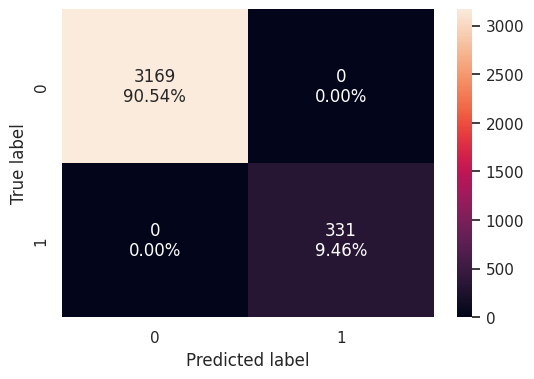

```python
# Compute and display the confusion matrix for the training set
confusion_matrix_sklearn(model, X_train, y_train)
```

```python
# Compute and display the performance metrics for the training set
decision_tree_perf_train = model_performance_classification_sklearn(
    model, X_train, y_train
)
decision_tree_perf_train
```

|  | Accuracy | Recall | Precision | F1 |
| --- | --- | --- | --- | --- |
| 0 | 1.0 | 1.0 | 1.0 | 1.0 |

- The classification model has achieved perfect performance metrics across the board, with an Accuracy, Recall, Precision, and F1-score all equal to 1.0. This indicates that the model correctly classified all instances, with no false positives or false negatives.
- While this is an ideal result, it is important to consider whether this performance is realistic or if it might indicate overfitting, especially if the model was evaluated on the training data or a non-representative test set

### Visualizing the Decision Tree for the training data

```python
# Extract and print feature names from the training dataset
feature_names = list(X_train.columns)
print(feature_names)
```

```
['Age', 'Income', 'Family', 'CCAvg', 'Mortgage', 'Securities_Account', 'CD_Account', 'Online', 'CreditCard', 'ZIPCode_91', 'ZIPCode_92', 'ZIPCode_93', 'ZIPCode_94', 'ZIPCode_95', 'ZIPCode_96', 'Education_Graduate', 'Education_Undergraduate']
```

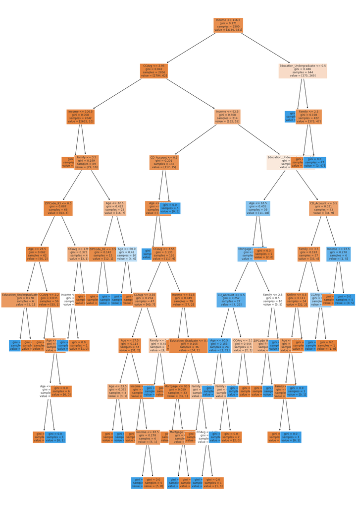

```python
# Display the Decision Tree for this training data
plt.figure(figsize=(20, 30))
out = tree.plot_tree(
    model,
    feature_names=feature_names,
    filled=True,
    fontsize=9,
    node_ids=False,
    class_names=None,
)
# Add arrows to the decision tree split if they are missing
for o in out:
    arrow = o.arrow_patch
    if arrow is not None:
        arrow.set_edgecolor("black")
        arrow.set_linewidth(1)
plt.show()
```

```python
# Text report showing the rules of a decision tree -
print(tree.export_text(model, feature_names=feature_names, show_weights=True))
```

```
|--- Income <= 116.50
|   |--- CCAvg <= 2.95
|   |   |--- Income <= 106.50
|   |   |   |--- weights: [2553.00, 0.00] class: 0
|   |   |--- Income >  106.50
|   |   |   |--- Family <= 3.50
|   |   |   |   |--- ZIPCode_93 <= 0.50
|   |   |   |   |   |--- Age <= 28.50
|   |   |   |   |   |   |--- Education_Undergraduate <= 0.50
|   |   |   |   |   |   |   |--- weights: [0.00, 1.00] class: 1
|   |   |   |   |   |   |--- Education_Undergraduate >  0.50
|   |   |   |   |   |   |   |--- weights: [5.00, 0.00] class: 0
|   |   |   |   |   |--- Age >  28.50
|   |   |   |   |   |   |--- CCAvg <= 2.20
|   |   |   |   |   |   |   |--- weights: [48.00, 0.00] class: 0
|   |   |   |   |   |   |--- CCAvg >  2.20
|   |   |   |   |   |   |   |--- Age <= 48.50
|   |   |   |   |   |   |   |   |--- Age <= 40.00
|   |   |   |   |   |   |   |   |   |--- weights: [1.00, 0.00] class: 0
|   |   |   |   |   |   |   |   |--- Age >  40.00
|   |   |   |   |   |   |   |   |   |--- weights: [0.00, 1.00] class: 1
|   |   |   |   |   |   |   |--- Age >  48.50
|   |   |   |   |   |   |   |   |--- weights: [6.00, 0.00] class: 0
|   |   |   |   |--- ZIPCode_93 >  0.50
|   |   |   |   |   |--- CCAvg <= 1.95
|   |   |   |   |   |   |--- Income <= 112.00
|   |   |   |   |   |   |   |--- weights: [0.00, 1.00] class: 1
|   |   |   |   |   |   |--- Income >  112.00
|   |   |   |   |   |   |   |--- weights: [1.00, 0.00] class: 0
|   |   |   |   |   |--- CCAvg >  1.95
|   |   |   |   |   |   |--- weights: [2.00, 0.00] class: 0
|   |   |   |--- Family >  3.50
|   |   |   |   |--- Age <= 32.50
|   |   |   |   |   |--- ZIPCode_92 <= 0.50
|   |   |   |   |   |   |--- weights: [12.00, 0.00] class: 0
|   |   |   |   |   |--- ZIPCode_92 >  0.50
|   |   |   |   |   |   |--- weights: [0.00, 1.00] class: 1
|   |   |   |   |--- Age >  32.50
|   |   |   |   |   |--- Age <= 60.00
|   |   |   |   |   |   |--- weights: [0.00, 6.00] class: 1
```

[output cut: 93 more lines]

```
|   |   |   |   |   |   |--- CCAvg >  4.20
|   |   |   |   |   |   |   |--- weights: [1.00, 0.00] class: 0
|   |   |   |   |--- CD_Account >  0.50
|   |   |   |   |   |--- Income <= 93.50
|   |   |   |   |   |   |--- weights: [1.00, 0.00] class: 0
|   |   |   |   |   |--- Income >  93.50
|   |   |   |   |   |   |--- weights: [0.00, 5.00] class: 1
|--- Income >  116.50
|   |--- Education_Undergraduate <= 0.50
|   |   |--- weights: [0.00, 222.00] class: 1
|   |--- Education_Undergraduate >  0.50
|   |   |--- Family <= 2.50
|   |   |   |--- weights: [375.00, 0.00] class: 0
|   |   |--- Family >  2.50
|   |   |   |--- weights: [0.00, 47.00] class: 1
```

```python
# Create and print a DataFrame of feature importances
# 1. Extract feature importances from the model
# 2. Create a DataFrame with importances and feature names computed as the  Gini importance
# 3. Display the result
print(
    pd.DataFrame(
        model.feature_importances_, columns=["Imp"], index=X_train.columns
    ).sort_values(by="Imp", ascending=False)
)
```

```
                              Imp
Education_Undergraduate  0.403732
Income                   0.305688
Family                   0.166733
CCAvg                    0.049492
Age                      0.032549
CD_Account               0.025711
Mortgage                 0.006250
ZIPCode_94               0.004767
ZIPCode_92               0.003080
Education_Graduate       0.000843
ZIPCode_93               0.000594
Online                   0.000561
Securities_Account       0.000000
CreditCard               0.000000
ZIPCode_91               0.000000
ZIPCode_96               0.000000
ZIPCode_95               0.000000
```

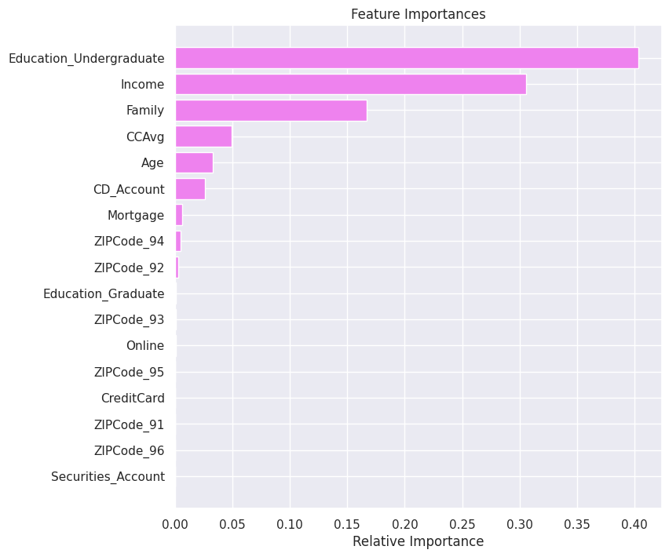

```python
# Visualize feature importances of the model
importances = model.feature_importances_
indices = np.argsort(importances)

# Create a bar plot of feature importances
plt.figure(figsize=(8, 8))
plt.title("Feature Importances")
plt.barh(range(len(indices)), importances[indices], color="violet", align="center")

# Customize y-axis with feature names
plt.yticks(range(len(indices)), [feature_names[i] for i in indices])

# Display the plot
plt.xlabel("Relative Importance")
plt.show()
```

#### Checking model performance on test data

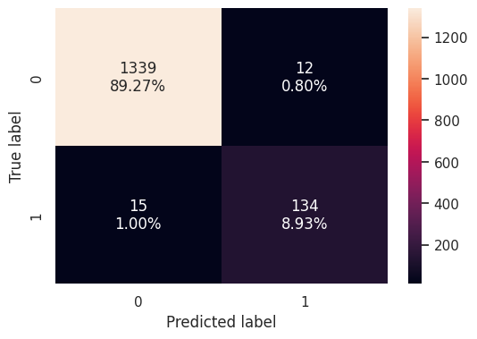

```python
# Compute and display the confusion matrix for the test set
confusion_matrix_sklearn(model, X_test, y_test)
```

```python
# Compute the performance metrics for the test set
decision_tree_perf_test = model_performance_classification_sklearn(
    model, X_test, y_test
)
# Display the performance metrics
decision_tree_perf_test
```

|  | Accuracy | Recall | Precision | F1 |
| --- | --- | --- | --- | --- |
| 0 | 0.982 | 0.899329 | 0.917808 | 0.908475 |

## Model Performance Improvement

### Pre-pruning

```python
# Choose the type of classifier.
estimator = DecisionTreeClassifier(random_state=1)

# Grid of parameters to choose from
parameters = {
    "max_depth": np.arange(6, 15),
    "min_samples_leaf": [1, 2, 5, 7, 10],
    "max_leaf_nodes": [2, 3, 5, 10],
}

# Type of scoring used to compare parameter combinations
acc_scorer = make_scorer(recall_score)

# Run the grid search
grid_obj = GridSearchCV(estimator, parameters, scoring=acc_scorer, cv=5)
grid_obj = grid_obj.fit(X_train, y_train)

# Set the clf to the best combination of parameters
estimator = grid_obj.best_estimator_

# Fit the best algorithm to the data.
estimator.fit(X_train, y_train)
```

```
DecisionTreeClassifier(max_depth=6, max_leaf_nodes=10, random_state=1)
```

### Checking performance on the training data

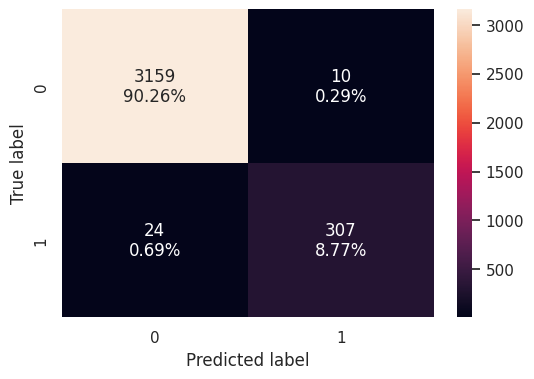

```python
# Compute and display the confusion matrix for the training set
confusion_matrix_sklearn(estimator, X_train, y_train)
```

```python
# Evaluate the performance of the tuned decision tree on the training data
decision_tree_tune_perf_train = model_performance_classification_sklearn(estimator, X_train, y_train)

# Display the performance metrics
decision_tree_tune_perf_train
```

|  | Accuracy | Recall | Precision | F1 |
| --- | --- | --- | --- | --- |
| 0 | 0.990286 | 0.927492 | 0.968454 | 0.947531 |

### Visualizing the Decision Tree

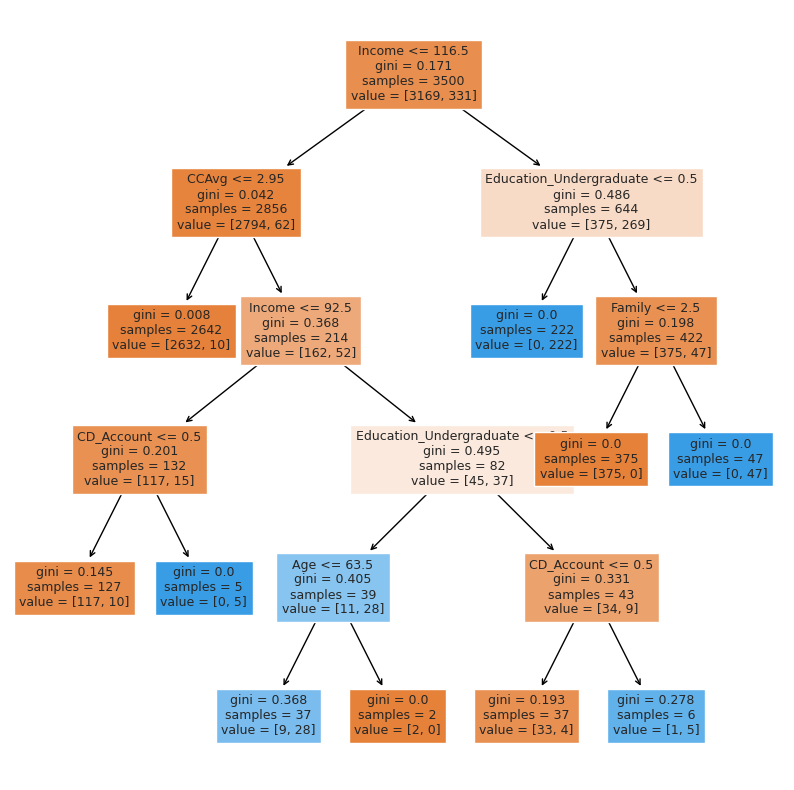

```python
# Display the Decision Tree for this training data
plt.figure(figsize=(10, 10))
out = tree.plot_tree(
    estimator,
    feature_names=feature_names,
    filled=True,
    fontsize=9,
    node_ids=False,
    class_names=None,
)
# Add arrows to the decision tree split if they are missing
for o in out:
    arrow = o.arrow_patch
    if arrow is not None:
        arrow.set_edgecolor("black")
        arrow.set_linewidth(1)
plt.show()
```

```python
# Text report showing the rules of a decision tree -
print(tree.export_text(estimator, feature_names=feature_names, show_weights=True))
```

```
|--- Income <= 116.50
|   |--- CCAvg <= 2.95
|   |   |--- weights: [2632.00, 10.00] class: 0
|   |--- CCAvg >  2.95
|   |   |--- Income <= 92.50
|   |   |   |--- CD_Account <= 0.50
|   |   |   |   |--- weights: [117.00, 10.00] class: 0
|   |   |   |--- CD_Account >  0.50
|   |   |   |   |--- weights: [0.00, 5.00] class: 1
|   |   |--- Income >  92.50
|   |   |   |--- Education_Undergraduate <= 0.50
|   |   |   |   |--- Age <= 63.50
|   |   |   |   |   |--- weights: [9.00, 28.00] class: 1
|   |   |   |   |--- Age >  63.50
|   |   |   |   |   |--- weights: [2.00, 0.00] class: 0
|   |   |   |--- Education_Undergraduate >  0.50
|   |   |   |   |--- CD_Account <= 0.50
|   |   |   |   |   |--- weights: [33.00, 4.00] class: 0
|   |   |   |   |--- CD_Account >  0.50
|   |   |   |   |   |--- weights: [1.00, 5.00] class: 1
|--- Income >  116.50
|   |--- Education_Undergraduate <= 0.50
|   |   |--- weights: [0.00, 222.00] class: 1
|   |--- Education_Undergraduate >  0.50
|   |   |--- Family <= 2.50
|   |   |   |--- weights: [375.00, 0.00] class: 0
|   |   |--- Family >  2.50
|   |   |   |--- weights: [0.00, 47.00] class: 1
```

```python
# Create and print a DataFrame of feature importances
# 1. Extract feature importances from the model
# 2. Create a DataFrame with importances and feature names computed as the  Gini importance
# 3. Display the result
print(
    pd.DataFrame(
        estimator.feature_importances_, columns=["Imp"], index=X_train.columns
    ).sort_values(by="Imp", ascending=False)
)
```

```
                              Imp
Education_Undergraduate  0.446191
Income                   0.327387
Family                   0.155083
CCAvg                    0.042061
CD_Account               0.025243
Age                      0.004035
Mortgage                 0.000000
Online                   0.000000
Securities_Account       0.000000
CreditCard               0.000000
ZIPCode_91               0.000000
ZIPCode_93               0.000000
ZIPCode_92               0.000000
ZIPCode_94               0.000000
ZIPCode_95               0.000000
ZIPCode_96               0.000000
Education_Graduate       0.000000
```

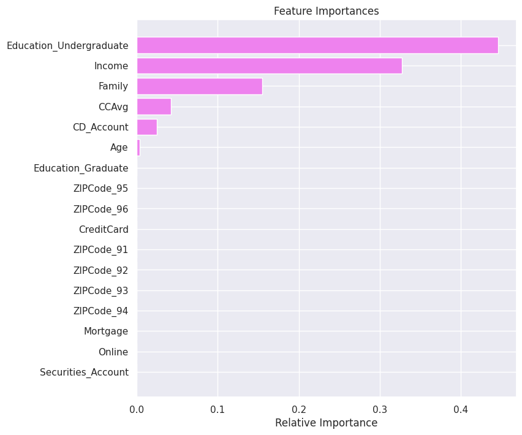

```python
# Visualize feature importances of the model
importances = estimator.feature_importances_
indices = np.argsort(importances)

# Create a bar plot of feature importances
plt.figure(figsize=(8, 8))
plt.title("Feature Importances")
plt.barh(range(len(indices)), importances[indices], color="violet", align="center")

# Customize y-axis with feature names
plt.yticks(range(len(indices)), [feature_names[i] for i in indices])

# Display the plot
plt.xlabel("Relative Importance")
plt.show()
```

### Checking the performance on the test data

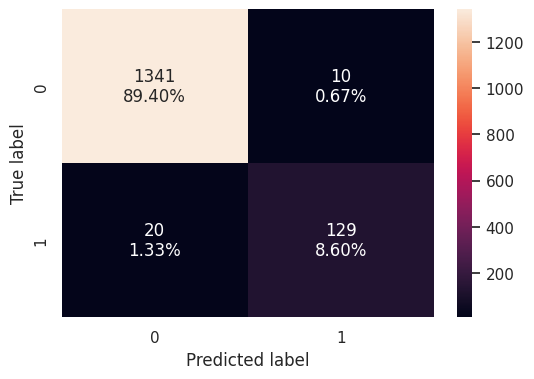

```python
# Compute and display the confusion matrix for the test set
confusion_matrix_sklearn(estimator, X_test, y_test)
```

```python
# Evaluate the performance of the tuned decision tree on the test data
decision_tree_tune_perf_test = model_performance_classification_sklearn(estimator, X_test, y_test)

# Display the performance metrics
decision_tree_tune_perf_test
```

|  | Accuracy | Recall | Precision | F1 |
| --- | --- | --- | --- | --- |
| 0 | 0.98 | 0.865772 | 0.928058 | 0.895833 |